# 6주차 복습문제

3조

### 다음 데이터는 Boston 근교의 집 값을 나타내는 데이터이다. 물음에 답하시오.

```r
library(MASS)
str(Boston)
```

```
## 'data.frame':    506 obs. of  14 variables:
##  $ crim   : num  0.00632 0.02731 0.02729 0.03237 0.06905 ...
##  $ zn     : num  18 0 0 0 0 0 12.5 12.5 12.5 12.5 ...
##  $ indus  : num  2.31 7.07 7.07 2.18 2.18 2.18 7.87 7.87 7.87 7.87 ...
##  $ chas   : int  0 0 0 0 0 0 0 0 0 0 ...
##  $ nox    : num  0.538 0.469 0.469 0.458 0.458 0.458 0.524 0.524 0.524 0.524 ...
##  $ rm     : num  6.58 6.42 7.18 7 7.15 ...
##  $ age    : num  65.2 78.9 61.1 45.8 54.2 58.7 66.6 96.1 100 85.9 ...
##  $ dis    : num  4.09 4.97 4.97 6.06 6.06 ...
##  $ rad    : int  1 2 2 3 3 3 5 5 5 5 ...
##  $ tax    : num  296 242 242 222 222 222 311 311 311 311 ...
##  $ ptratio: num  15.3 17.8 17.8 18.7 18.7 18.7 15.2 15.2 15.2 15.2 ...
##  $ black  : num  397 397 393 395 397 ...
##  $ lstat  : num  4.98 9.14 4.03 2.94 5.33 ...
##  $ medv   : num  24 21.6 34.7 33.4 36.2 28.7 22.9 27.1 16.5 18.9 ...
```

### 변수 설명

> CRIM : Town별 1인당 범죄율  
> ZN : 25000 평방피트를 초고하는 거주지역 비율  
> INDUS : 비소매상업지역이 점유한 토지 비율  
> CHAS :찰스 강의 근처 여부 (경계에 있을 시 1 , 아니면 0)  
> NOX : 10ppm 당 농축 일산화질소  
> RM : 주택 1가구당 평균 방 갯수  
> AGE : 1940년 이전 건축된 주택 비율  
> DIS : 5개 보스턴 직업센터까지의 접근성 지수  
> RAD : 방사형 도로까지의 접근성 지수  
> TAX : 10000 달러 당 재산세율  
> PTRATIO : Town 별 학생/교사 비율  
> B : Town 별 흑인의 비율  
> LSTAT : 하위계층의 비율  
> MEDV : 본인 소유 주택가격(Median , 단위:$1000)

## 1. 주택가격을 예측하기 위한 회귀트리를 만들고자 한다.

## 전체 데이터를 Train, Test (7:3) 으로 나눈 후 , 모델을 적합하라.

## 또한 각 속성 중 가장 중요한 속성을 설명하라. (제시한 변수 설명 참고할 것.)

```r
set.seed(6318)

train=sample(1:nrow(Boston),nrow(Boston)*0.7)

Boston_train=Boston[train,]
Boston_test=Boston[-train,]


library(rpart)

Boston_tree=rpart(medv~., data=Boston_train)
summary(Boston_tree)
```

```
## Call:
## rpart(formula = medv ~ ., data = Boston_train)
##   n= 354
##
##           CP nsplit rel error    xerror       xstd
## 1 0.48747646      0 1.0000000 1.0061507 0.10186345
## 2 0.16282255      1 0.5125235 0.5541957 0.06066950
## 3 0.05307845      2 0.3497010 0.3992149 0.05079165
## 4 0.04909119      3 0.2966225 0.3803477 0.05340625
## 5 0.02985132      4 0.2475314 0.3160043 0.04553977
## 6 0.01455216      5 0.2176800 0.2878281 0.04553253
## 7 0.01090196      6 0.2031279 0.2642110 0.04280747
## 8 0.01000000      7 0.1922259 0.2555753 0.04279429
##
## Variable importance
##      rm   lstat ptratio   indus     tax     nox     age     dis      zn
##      34      23       8       6       5       5       5       5       4
##    crim     rad   black
##       3       2       1
##
## Node number 1: 354 observations,    complexity param=0.4874765
##   mean=22.58418, MSE=85.44495
##   left son=2 (307 obs) right son=3 (47 obs)
##   Primary splits:
##       rm      < 6.978    to the left,  improve=0.4874765, (0 missing)
##       lstat   < 5.165    to the right, improve=0.4439840, (0 missing)
##       indus   < 3.985    to the right, improve=0.2585544, (0 missing)
##       ptratio < 18.75    to the right, improve=0.2457061, (0 missing)
##       nox     < 0.6635   to the right, improve=0.2171589, (0 missing)
##   Surrogate splits:
##       lstat   < 4.475    to the right, agree=0.915, adj=0.362, (0 split)
##       ptratio < 14.55    to the right, agree=0.895, adj=0.213, (0 split)
##       zn      < 87.5     to the left,  agree=0.879, adj=0.085, (0 split)
##       indus   < 1.605    to the right, agree=0.876, adj=0.064, (0 split)
##       crim    < 0.013355 to the right, agree=0.870, adj=0.021, (0 split)
##
## Node number 2: 307 observations,    complexity param=0.1628226
##   mean=20.05896, MSE=39.61486
##   left son=4 (123 obs) right son=5 (184 obs)
##   Primary splits:
```

[output cut: 100 more lines]

```
##       crim    < 0.03864  to the right, agree=0.762, adj=0.231, (0 split)
##       zn      < 36.5     to the left,  agree=0.762, adj=0.231, (0 split)
##       nox     < 0.4185   to the right, agree=0.762, adj=0.231, (0 split)
##
## Node number 14: 8 observations
##   mean=40.1875, MSE=78.34359
##
## Node number 15: 14 observations
##   mean=48.23571, MSE=6.223724
##
## Node number 22: 29 observations
##   mean=26.38966, MSE=8.311962
##
## Node number 23: 13 observations
##   mean=33.39231, MSE=40.82994
```

> variable importance를 살펴보면 rm : 34 , lstat : 23 으로  
> 다른 변수에 비해 중요도가 굉장히 높은 것으로 나타났다.  
> 즉, 주택가격에 있어서 주택 1가구당 평균 방의 갯수와  
> 하위계층의 비율 여부가 가장 중요한 것으로 보인다.

## 1-1. 적합한 모델을 토대로 plot을 그리고,

## 가장 저렴한 집 값의 조건을 서술하고, RSS를 구하여

## 그 의미를 서술하라. (제시한 변수설명 참고할 것.)

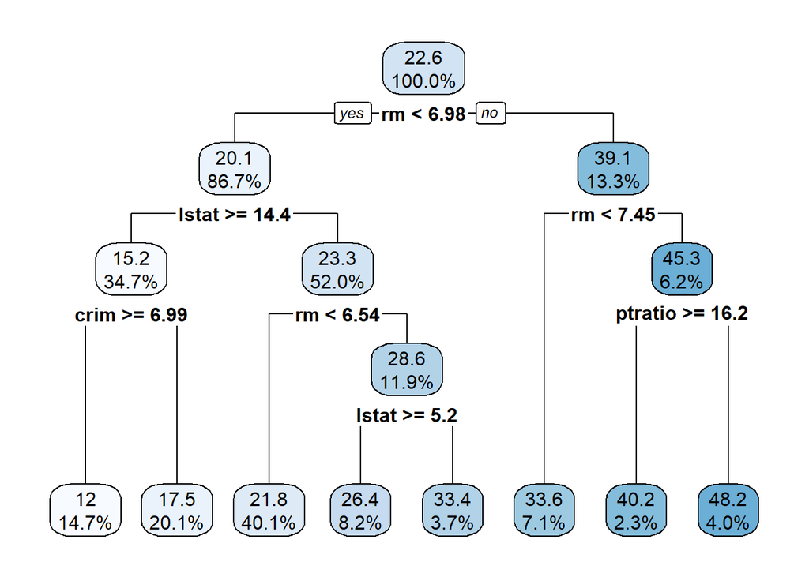

```r
library(rpart.plot)
rpart.plot(Boston_tree,digits=3)
```

```r
pred_tree=predict(Boston_tree,newdata = Boston_test)

sqrt(mean((pred_tree-Boston[-train,"medv"])^2))
```

```
## [1] 4.912084
```

## 2. 과적합 방지를 위해 앞서 구한 모델을 가지치기하려고 한다.

## CP와 plot을이용해 최적의 트리 크기를 구하고

## 그에 대한 근거를 구하시오.

```r
printcp(Boston_tree)
```

```
##
## Regression tree:
## rpart(formula = medv ~ ., data = Boston_train)
##
## Variables actually used in tree construction:
## [1] crim    lstat   ptratio rm
##
## Root node error: 30248/354 = 85.445
##
## n= 354
##
##         CP nsplit rel error  xerror     xstd
## 1 0.487476      0   1.00000 1.00615 0.101863
## 2 0.162823      1   0.51252 0.55420 0.060670
## 3 0.053078      2   0.34970 0.39921 0.050792
## 4 0.049091      3   0.29662 0.38035 0.053406
## 5 0.029851      4   0.24753 0.31600 0.045540
## 6 0.014552      5   0.21768 0.28783 0.045533
## 7 0.010902      6   0.20313 0.26421 0.042807
## 8 0.010000      7   0.19223 0.25558 0.042794
```

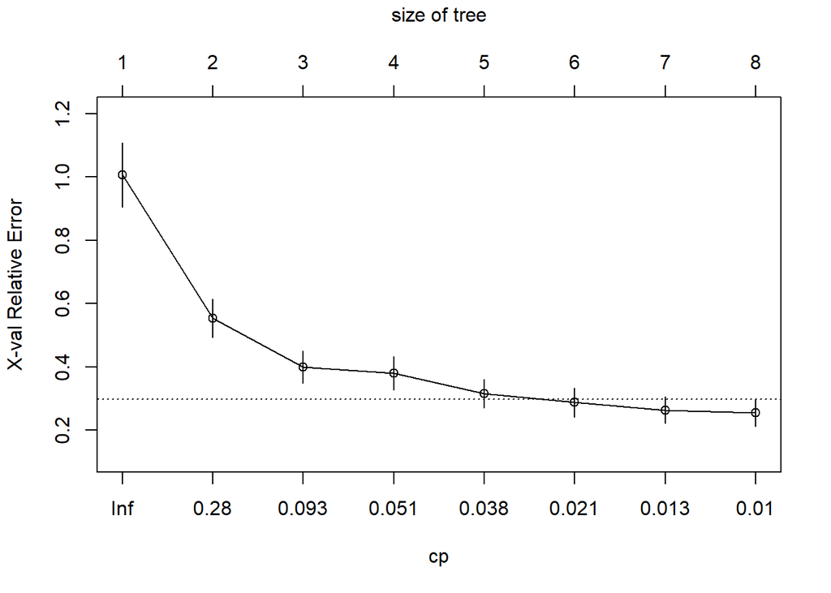

```r
plotcp(Boston_tree)
```

## 2-1. Pruning 과정 이후의 모델을 구하고,

## MAE와 상관관계 및 전체 예측값의 범위를 구하여,

## 모델 성능을 비교하라.

```r
library(tree)
```

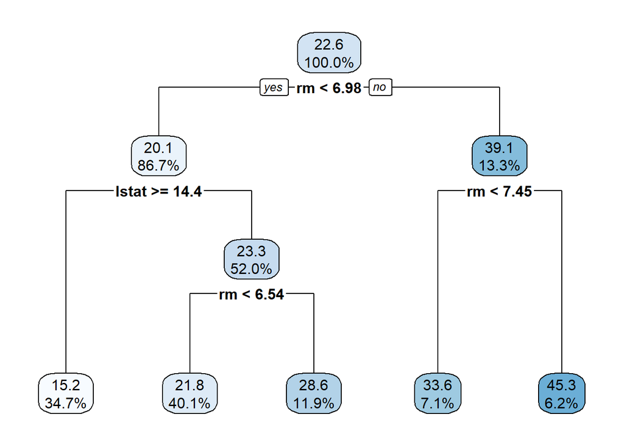

```r
Boston_pru=prune.rpart(Boston_tree,
                       cp=Boston_tree$cptable[5,"CP"])

rpart.plot(Boston_pru,digits = 3)
```

```r
pred_pru=predict(Boston_pru,newdata = Boston_test)
pred_tree=predict(Boston_tree,newdata = Boston_test)

summary(pred_pru) ; summary(pred_tree) ; summary(Boston_test$medv)
```

```
##    Min. 1st Qu.  Median    Mean 3rd Qu.    Max.
##   15.16   15.16   21.79   22.66   28.56   45.31
```

```
##    Min. 1st Qu.  Median    Mean 3rd Qu.    Max.
##   11.99   17.48   21.79   22.74   26.39   48.24
```

```
##    Min. 1st Qu.  Median    Mean 3rd Qu.    Max.
##    5.00   16.15   21.55   22.41   25.05   50.00
```

```r
MAE=function(actual, predicted){
  mean(abs(actual-predicted))
}


MAE(pred_pru, Boston_test$medv) ; MAE(pred_tree, Boston_test$medv)
```

```
## [1] 3.210686
```

```
## [1] 3.133343
```

```r
cor(pred_pru, Boston_test$medv) ; cor(pred_tree, Boston_test$medv)
```

```
## [1] 0.8334488
```

```
## [1] 0.842344
```

> MAE, 및 상관관계 측면에서 오히려 성능이 떨어졌다.  
> Pruning을 하지 않는 것이 맞다고 볼 수 있다.

## 3. 새로운 함수를 통해 모델을 적합하고자 한다.

## 모델 트리를 이용하여 새로운 모델을 구하고

## 앞서 사용한 방법으로 모델 성능을 비교하라.

## 또한 주어진 조건의 예상 집 값을 해당 모델을 통해 구하라.

```r
library(RWeka)
set.seed(6318)

Boston_mod=M5P(medv~., data=Boston_train, option=T)
Boston_mod
```

```
## M5 pruned model tree:
## (using smoothed linear models)
##
## rm <= 6.676 :
## |   lstat <= 14.4 :
## |   |   lstat <= 9.63 : LM1 (75/25.352%)
## |   |   lstat >  9.63 :
## |   |   |   ptratio <= 17.85 : LM2 (20/15.428%)
## |   |   |   ptratio >  17.85 :
## |   |   |   |   indus <= 10.245 : LM3 (35/12.796%)
## |   |   |   |   indus >  10.245 : LM4 (27/19.511%)
## |   lstat >  14.4 : LM5 (115/26.124%)
## rm >  6.676 :
## |   rm <= 7.445 : LM6 (60/39.988%)
## |   rm >  7.445 : LM7 (22/37.925%)
##
## LM num: 1
## medv =
##  2.1533 * crim
##  + 0.0271 * zn
##  - 0.2847 * indus
##  - 10.4084 * nox
##  + 3.3317 * rm
##  - 0.025 * age
##  - 1.1232 * dis
##  + 0.3926 * rad
##  - 0.0101 * tax
##  - 0.1789 * ptratio
##  + 0.0032 * black
##  - 0.1532 * lstat
##  + 20.0934
##
## LM num: 2
## medv =
##  -0.0191 * crim
##  + 0.0096 * zn
##  - 3.5284 * nox
##  + 0.1962 * rm
##  - 0.4378 * dis
##  + 0.1006 * rad
```

[output cut: 68 more lines]

```
## medv =
##  -5.2157 * crim
##  + 0.0082 * zn
##  + 0.5467 * indus
##  - 10.9469 * nox
##  + 5.5414 * rm
##  - 0.703 * dis
##  + 0.1559 * rad
##  - 0.002 * tax
##  - 1.6711 * ptratio
##  + 0.0019 * black
##  - 0.5523 * lstat
##  + 34.3879
##
## Number of Rules : 7
```

```r
pred_mod=predict(Boston_mod,newdata = Boston_test)

summary(pred_mod) ; summary(pred_tree)
```

```
##    Min. 1st Qu.  Median    Mean 3rd Qu.    Max.
##    3.17   16.21   21.55   22.52   25.99   46.82
```

```
##    Min. 1st Qu.  Median    Mean 3rd Qu.    Max.
##   11.99   17.48   21.79   22.74   26.39   48.24
```

```r
MAE=function(actual, predicted){
  mean(abs(actual-predicted))
}


MAE(pred_mod, Boston_test$medv) ; MAE(pred_tree, Boston_test$medv)
```

```
## [1] 2.472244
```

```
## [1] 3.133343
```

```r
cor(pred_mod, Boston_test$medv) ; cor(pred_tree, Boston_test$medv)
```

```
## [1] 0.9165052
```

```
## [1] 0.842344
```

> 주어진 조건으로 보아 LM4가 적당한 것으로 보임.  
> rm : 6 , lstat : 12.6 , ptratio : 18.4 , indus : 11.13

```r
medv=   -0.0191 * 3.613 + 0.0096 * 11.36    + 0.0237 * 11.13- 3.5284 * 0.554 - 0.624 * 6 -
   0.0056 * 68.57   - 0.4487 * 3.795 + 0.1006 * 9.5 - 0.0037 * 408.2 - 0.2241 * 18.4 +
    0.0124 * 356 - 0.1468 * 12.6  + 30.4487

medv
```

```
## [1] 20.85363
```

> 해당 조건의 집 값은 약 $ 20853 라고 할 수 있다.